# A crash course on NumPy for images

Images in `scikit-image` are represented by NumPy ndarrays. Hence, many common operations can be achieved using standard NumPy methods for manipulating arrays:

```
>>> from skimage import data
>>> camera = data.camera()
>>> type(camera)
<type 'numpy.ndarray'>
```

Retrieving the geometry of the image and the number of pixels:

```
>>> camera.shape
(512, 512)
>>> camera.size
262144
```

Retrieving statistical information about image intensity values:

```
>>> camera.min(), camera.max()
(0, 255)
>>> camera.mean()
118.31400299072266
```

NumPy arrays representing images can be of different integer or float numerical types. See Image data types and what they mean for more information about these types and how `scikit-image` treats them.

## NumPy indexing

NumPy indexing can be used both for looking at the pixel values and to modify them:

```
>>> # Get the value of the pixel at the 10th row and 20th column
>>> camera[10, 20]
153
>>> # Set to black the pixel at the 3rd row and 10th column
>>> camera[3, 10] = 0
```

Be careful! In NumPy indexing, the first dimension (`camera.shape[0]`) corresponds to rows, while the second (`camera.shape[1]`) corresponds to columns, with the origin (`camera[0, 0]`) at the top-left corner. This matches matrix/linear algebra notation, but is in contrast to Cartesian (x, y) coordinates. See Coordinate conventions below for more details.

Beyond individual pixels, it is possible to access/modify values of whole sets of pixels using the different indexing capabilities of NumPy.

Slicing:

```
>>> # Set the first ten lines to "black" (0)
>>> camera[:10] = 0
```

Masking (indexing with masks of booleans):

```
>>> mask = camera < 87
>>> # Set to "white" (255) the pixels where mask is True
>>> camera[mask] = 255
```

Fancy indexing (indexing with sets of indices):

```
>>> inds_r = np.arange(len(camera))
>>> inds_c = 4 * inds_r % len(camera)
>>> camera[inds_r, inds_c] = 0
```

Masks are very useful when you need to select a set of pixels on which to perform the manipulations. The mask can be any boolean array of the same shape as the image (or a shape broadcastable to the image shape). This can be used to define a region of interest, for example, a disk:

```
>>> nrows, ncols = camera.shape
>>> row, col = np.ogrid[:nrows, :ncols]
>>> cnt_row, cnt_col = nrows / 2, ncols / 2
>>> outer_disk_mask = ((row - cnt_row)**2 + (col - cnt_col)**2 >
...                    (nrows / 2)**2)
>>> camera[outer_disk_mask] = 0
```

[figure not shown]

Boolean operations from NumPy can be used to define even more complex masks:

```
>>> lower_half = row > cnt_row
>>> lower_half_disk = np.logical_and(lower_half, outer_disk_mask)
>>> camera = data.camera()
>>> camera[lower_half_disk] = 0
```

## Color images

All of the above remains true for color images. A color image is a NumPy array with an additional trailing dimension for the channels:

```
>>> cat = data.chelsea()
>>> type(cat)
<type 'numpy.ndarray'>
>>> cat.shape
(300, 451, 3)
```

This shows that `cat` is a 300-by-451 pixel image with three channels (red, green, and blue). As before, we can get and set the pixel values:

```
>>> cat[10, 20]
array([151, 129, 115], dtype=uint8)
>>> # Set the pixel at (50th row, 60th column) to "black"
>>> cat[50, 60] = 0
>>> # set the pixel at (50th row, 61st column) to "green"
>>> cat[50, 61] = [0, 255, 0]  # [red, green, blue]
```

We can also use 2D boolean masks for 2D multichannel images, as we did with the grayscale image above:

Using a 2D mask on a 2D color image

```
>>> from skimage import data
>>> cat = data.chelsea()
>>> reddish = cat[:, :, 0] > 160
>>> cat[reddish] = [0, 255, 0]
>>> plt.imshow(cat)
```

(Source code, png, pdf)

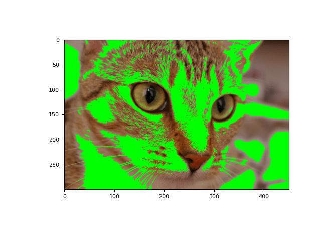

## Coordinate conventions

Because `scikit-image` represents images using NumPy arrays, the coordinate conventions must match. Two-dimensional (2D) grayscale images (such as `camera` above) are indexed by rows and columns (abbreviated to either `(row, col)` or `(r, c)`), with the lowest element `(0, 0)` at the top-left corner. In various parts of the library, you will also see `rr` and `cc` refer to lists of row and column coordinates. We distinguish this convention from `(x, y)`, which commonly denote standard Cartesian coordinates, where `x` is the horizontal coordinate, `y` - the vertical one, and the origin is at the bottom left (Matplotlib axes, for example, use this convention).

In the case of multichannel images, the last dimension is used for color channels and is denoted by `channel` or `ch`.

Finally, for volumetric (3D) images, such as videos, magnetic resonance imaging (MRI) scans, confocal microscopy, etc. we refer to the leading dimension as `plane`, abbreviated as `pln` or `p`.

These conventions are summarized below:

Dimension name and order conventions in scikit-image

| Image type | Coordinates |
| --- | --- |
| 2D grayscale | (row, col) |
| 2D multichannel (eg. RGB) | (row, col, ch) |
| 3D grayscale | (pln, row, col) |
| 3D multichannel | (pln, row, col, ch) |

Many functions in `scikit-image` can operate on 3D images directly:

```
>>> im3d = np.random.rand(100, 1000, 1000)
>>> from skimage import morphology
>>> from scipy import ndimage as ndi
>>> seeds = ndi.label(im3d < 0.1)[0]
>>> ws = morphology.watershed(im3d, seeds)
```

In many cases, however, the third spatial dimension has lower resolution than the other two. Some `scikit-image` functions provide a `spacing` keyword argument to help handle this kind of data:

```
>>> from skimage import segmentation
>>> slics = segmentation.slic(im3d, spacing=[5, 1, 1], multichannel=False)
```

Other times, the processing must be done plane-wise. When planes are stacked along the leading dimension (in agreement with our convention), the following syntax can be used:

```
>>> from skimage import filters
>>> edges = np.empty_like(im3d)
>>> for pln, image in enumerate(im3d):
...     # Iterate over the leading dimension
...     edges[pln] = filters.sobel(image)
```

## Notes on the order of array dimensions

Although the labeling of the axes might seem arbitrary, it can have a significant effect on the speed of operations. This is because modern processors never retrieve just one item from memory, but rather a whole chunk of adjacent items (an operation called prefetching). Therefore, processing of elements that are next to each other in memory is faster than processing them when they are scattered, even if the number of operations is the same:

```
>>> def in_order_multiply(arr, scalar):
...     for plane in list(range(arr.shape[0])):
...         arr[plane, :, :] *= scalar
...
>>> def out_of_order_multiply(arr, scalar):
...     for plane in list(range(arr.shape[2])):
...         arr[:, :, plane] *= scalar
...
>>> import time
>>> im3d = np.random.rand(100, 1024, 1024)
>>> t0 = time.time(); x = in_order_multiply(im3d, 5); t1 = time.time()
>>> print("%.2f seconds" % (t1 - t0))
0.14 seconds
>>> s0 = time.time(); x = out_of_order_multiply(im3d, 5); s1 = time.time()
>>> print("%.2f seconds" % (s1 - s0))
1.18 seconds
>>> print("Speedup: %.1fx" % ((s1 - s0) / (t1 - t0)))
Speedup: 8.6x
```

When the last/rightmost dimension becomes even larger the speedup is even more dramatic. It is worth thinking about *data locality* when developing algorithms. In particular, `scikit-image` uses C-contiguous arrays by default. When using nested loops, the last/rightmost dimension of the array should be in the innermost loop of the computation. In the example above, the `*=` numpy operator iterates over all remaining dimensions.

## A note on the time dimension

Although `scikit-image` does not currently provide functions to work specifically with time-varying 3D data, its compatibility with NumPy arrays allows us to work quite naturally with a 5D array of the shape (t, pln, row, col, ch):

```
>>> for timepoint in image5d:
...     # Each timepoint is a 3D multichannel image
...     do_something_with(timepoint)
```

We can then supplement the above table as follows:

Addendum to dimension names and orders in scikit-image

| Image type | coordinates |
| --- | --- |
| 2D color video | (t, row, col, ch) |
| 3D multichannel video | (t, pln, row, col, ch) |

© 2019 the scikit-image team  
Licensed under the BSD 3-clause License.  
https://scikit-image.org/docs/0.18.x/user_guide/numpy_images.html